# Investigate_a_Dataset

## Project 2 : Investigate a Dataset (TMDB Movie Analysis)

- Introduction
- Data Wrangling
- Exploratory Data Analysis
- Conclusions

## Introduction

In this project, I have analysed TMDB dataset, which is available on Kaggle. This dataset contains information related to arround 10,000 movies collected from TMDB (www.themoviedb.org).It includes information about movie's viewer's rating,budget, revenue, genres, production companies, director, casting, keywords associated with movies, popularity of the movies and runtime.

This dataset can help to understand various factors like profitability, the trend around runtime, popularity over the years, popular genres for the profitability, connection between popularity ratings and profit; reveal information like profitable directors, casts and production companies over the span.

I am focusing on answering the following questions for this Movie dataset:

#### Q1. List of Generic questions based on the datset that can be answered are:

1. Which movie had the highest and lowest profit?
2. Which movie had the highest and lowest budget?
3. Which movie had the highest and lowest revenue?
4. What is the average runtime of all movies?
5. Which duration movies are most liked by the audiences according to their popularity?

#### Q2. List of Questions that can be answered based on the Profit of movies making more then 25M Dollars:

1. What is the average budget of the movie?
2. What is the average revenue of the movie?
3. Which are the most frequent cast involved?
4. Which are the successful genres?

```python
# Load your data and print out a few lines. Perform operations to inspect data

#importing packages
import numpy as np
import pandas as pd
import csv
import matplotlib.pyplot as plt
import seaborn as sns
%matplotlib inline
```

## Data Wrangling

During this step, we are going to import the csv file and display its main information. We will perform the following steps:

- Display the info of the dataset and get the idea of the size, number of records and number of columns
- Familiarize with the dataset and find any unusal values

```python
# After discussing the structure of the data and any problems that need to be
# cleaned, perform those cleaning steps in the second part of this section.

#importing csv dataset

df = pd.read_csv('http://d17h27t6h515a5.cloudfront.net/topher/2017/October/59dd1c4c_tmdb-movies/tmdb-movies.csv')
print("Original TMDB Dataset contains (Rows,Columns) : ",df.shape)
df.shape
```

```
Original TMDB Dataset contains (Rows,Columns) :  (10866, 21)
```

```
(10866, 21)
```

```python
df.head(2)
```

|  | id | imdb_id | popularity | budget | revenue | original_title | cast | homepage | director | tagline | ... | overview | runtime | genres | production_companies | release_date | vote_count | vote_average | release_year | budget_adj | revenue_adj |
| --- | --- | --- | --- | --- | --- | --- | --- | --- | --- | --- | --- | --- | --- | --- | --- | --- | --- | --- | --- | --- | --- |
| 0 | 135397 | tt0369610 | 32.985763 | 150000000 | 1513528810 | Jurassic World | Chris Pratt\|Bryce Dallas Howard\|Irrfan Khan\|Vi... | http://www.jurassicworld.com/ | Colin Trevorrow | The park is open. | ... | Twenty-two years after the events of Jurassic ... | 124 | Action\|Adventure\|Science Fiction\|Thriller | Universal Studios\|Amblin Entertainment\|Legenda... | 6/9/15 | 5562 | 6.5 | 2015 | 1.379999e+08 | 1.392446e+09 |
| 1 | 76341 | tt1392190 | 28.419936 | 150000000 | 378436354 | Mad Max: Fury Road | Tom Hardy\|Charlize Theron\|Hugh Keays-Byrne\|Nic... | http://www.madmaxmovie.com/ | George Miller | What a Lovely Day. | ... | An apocalyptic story set in the furthest reach... | 120 | Action\|Adventure\|Science Fiction\|Thriller | Village Roadshow Pictures\|Kennedy Miller Produ... | 5/13/15 | 6185 | 7.1 | 2015 | 1.379999e+08 | 3.481613e+08 |

2 rows × 21 columns

```python
#Explore the information of the dataset

print("Quick glance at the dataset for some statistical values: \n\n")
df.describe()
```

```
Quick glance at the dataset for some statistical values:
```

|  | id | popularity | budget | revenue | runtime | vote_count | vote_average | release_year | budget_adj | revenue_adj |
| --- | --- | --- | --- | --- | --- | --- | --- | --- | --- | --- |
| count | 10866.000000 | 10866.000000 | 1.086600e+04 | 1.086600e+04 | 10866.000000 | 10866.000000 | 10866.000000 | 10866.000000 | 1.086600e+04 | 1.086600e+04 |
| mean | 66064.177434 | 0.646441 | 1.462570e+07 | 3.982332e+07 | 102.070863 | 217.389748 | 5.974922 | 2001.322658 | 1.755104e+07 | 5.136436e+07 |
| std | 92130.136561 | 1.000185 | 3.091321e+07 | 1.170035e+08 | 31.381405 | 575.619058 | 0.935142 | 12.812941 | 3.430616e+07 | 1.446325e+08 |
| min | 5.000000 | 0.000065 | 0.000000e+00 | 0.000000e+00 | 0.000000 | 10.000000 | 1.500000 | 1960.000000 | 0.000000e+00 | 0.000000e+00 |
| 25% | 10596.250000 | 0.207583 | 0.000000e+00 | 0.000000e+00 | 90.000000 | 17.000000 | 5.400000 | 1995.000000 | 0.000000e+00 | 0.000000e+00 |
| 50% | 20669.000000 | 0.383856 | 0.000000e+00 | 0.000000e+00 | 99.000000 | 38.000000 | 6.000000 | 2006.000000 | 0.000000e+00 | 0.000000e+00 |
| 75% | 75610.000000 | 0.713817 | 1.500000e+07 | 2.400000e+07 | 111.000000 | 145.750000 | 6.600000 | 2011.000000 | 2.085325e+07 | 3.369710e+07 |
| max | 417859.000000 | 32.985763 | 4.250000e+08 | 2.781506e+09 | 900.000000 | 9767.000000 | 9.200000 | 2015.000000 | 4.250000e+08 | 2.827124e+09 |

```python
#Check column names and datatypes

print("Check columns and their data types: \n\n")
df.info()
```

```
Check columns and their data types:


<class 'pandas.core.frame.DataFrame'>
RangeIndex: 10866 entries, 0 to 10865
Data columns (total 21 columns):
id                      10866 non-null int64
imdb_id                 10856 non-null object
popularity              10866 non-null float64
budget                  10866 non-null int64
revenue                 10866 non-null int64
original_title          10866 non-null object
cast                    10790 non-null object
homepage                2936 non-null object
director                10822 non-null object
tagline                 8042 non-null object
keywords                9373 non-null object
overview                10862 non-null object
runtime                 10866 non-null int64
genres                  10843 non-null object
production_companies    9836 non-null object
release_date            10866 non-null object
vote_count              10866 non-null int64
vote_average            10866 non-null float64
release_year            10866 non-null int64
budget_adj              10866 non-null float64
revenue_adj             10866 non-null float64
dtypes: float64(4), int64(6), object(11)
memory usage: 1.7+ MB
```

# Data Cleaning and Further analysis

### Observations based on accessing the TMDB dataset file

1. The columns 'id', 'imdb_id','budget_adj', 'revenue_adj', 'homepage', 'keywords', 'tagline','overview' are not relevant for the analysis, so we can remove them.
2. Lets delete the one duplicated row that we have in our dataset.
3. There are lots of movies where the budget or revenue have a value of '0' which means that the values of those movies has not been recorded. So we need to discard this rows, since we cannot calculate profit of such movies
4. The 'release_date' column must be converted into date format.
5. Convert budget and revenue column to int datatype.
6. Replace runtime value of 0 to NAN, Since it will affect the result..
7. The dataset has not provided the currency for columns we will be dealing with hence we will assume it is in dollars.
8. Even the vote count is not same for all the movies and hence this affects the vote average column.
9. There are some invalid characters in cast and keywords, in our analysis of top keywords and casts, those are not creating any issues, so we have not cleaned those columns.

*First Step* : The columns 'id', 'imdb_id','budget_adj', 'revenue_adj', 'homepage', 'keywords', 'tagline','overview' are not relevant for the analysis, so we can remove them.

```python
# Columns that needs to be deleted
deleted_columns = [ 'id', 'imdb_id','budget_adj', 'revenue_adj', 'homepage', 'keywords', 'tagline','overview']

# Drop the columns from the database
df.drop(deleted_columns, axis=1, inplace=True)

# Lets look at the new dataset
df.head()
```

|  | popularity | budget | revenue | original_title | cast | director | runtime | genres | production_companies | release_date | vote_count | vote_average | release_year |
| --- | --- | --- | --- | --- | --- | --- | --- | --- | --- | --- | --- | --- | --- |
| 0 | 32.985763 | 150000000 | 1513528810 | Jurassic World | Chris Pratt\|Bryce Dallas Howard\|Irrfan Khan\|Vi... | Colin Trevorrow | 124 | Action\|Adventure\|Science Fiction\|Thriller | Universal Studios\|Amblin Entertainment\|Legenda... | 6/9/15 | 5562 | 6.5 | 2015 |
| 1 | 28.419936 | 150000000 | 378436354 | Mad Max: Fury Road | Tom Hardy\|Charlize Theron\|Hugh Keays-Byrne\|Nic... | George Miller | 120 | Action\|Adventure\|Science Fiction\|Thriller | Village Roadshow Pictures\|Kennedy Miller Produ... | 5/13/15 | 6185 | 7.1 | 2015 |
| 2 | 13.112507 | 110000000 | 295238201 | Insurgent | Shailene Woodley\|Theo James\|Kate Winslet\|Ansel... | Robert Schwentke | 119 | Adventure\|Science Fiction\|Thriller | Summit Entertainment\|Mandeville Films\|Red Wago... | 3/18/15 | 2480 | 6.3 | 2015 |
| 3 | 11.173104 | 200000000 | 2068178225 | Star Wars: The Force Awakens | Harrison Ford\|Mark Hamill\|Carrie Fisher\|Adam D... | J.J. Abrams | 136 | Action\|Adventure\|Science Fiction\|Fantasy | Lucasfilm\|Truenorth Productions\|Bad Robot | 12/15/15 | 5292 | 7.5 | 2015 |
| 4 | 9.335014 | 190000000 | 1506249360 | Furious 7 | Vin Diesel\|Paul Walker\|Jason Statham\|Michelle ... | James Wan | 137 | Action\|Crime\|Thriller | Universal Pictures\|Original Film\|Media Rights ... | 4/1/15 | 2947 | 7.3 | 2015 |

Let's see the number of entries in our dataset now.

```python
# Store rows and columns using shape function.
rows, col = df.shape

#since rows includes count of a header, we need to remove its count.
print('We have {} total rows and {} columns.'.format(rows-1, col))
```

[output not shown]

```python
# Find duplicates in the row
sum(df.duplicated())
```

```
1
```

*Second Step* : Lets delete the one duplicated row that we have

```python
# Drop duplicate rows but keep the first one
df.drop_duplicates(keep = 'first', inplace = True)

# Store rows and columns using shape function.
rows, col = df.shape

print('Now we have {} total rows and {} columns.'.format(rows-1, col))
```

[output not shown]

*Third Step* : There are lots of movies where the budget or revenue have a value of '0' which means that the values of those movies has not been recorded. So we need to discard these rows,as profit cannot be calculated

```python
# Columns that need to be checked.
columns = ['budget', 'revenue']

# Replace 0 with NAN
df[columns] = df[columns].replace(0, np.NaN)

# Drop rows which contains NAN
df.dropna(subset = columns, inplace = True)

rows, col = df.shape
print('We now have only {} rows.'.format(rows-1))
```

[output not shown]

*Fourth Step* : The 'release_date' column must be converted into date format.

```python
# Changing the format of dates:

df['release_date'] = pd.to_datetime(df['release_date'], errors = 'ignore')
print("Year range - ", df.release_year.min(), "to" ,df.release_year.max())
```

```
Year range -  1960 to 2015
```

*Fifth Step* : Convert budget and revenue column to int datatype.

```python
# Columns to convert datatype of
columns = ['budget', 'revenue']

# Convert budget and revenue column to int datatype
df[columns] = df[columns].applymap(np.int64)

# Lets look at the new datatype
df.dtypes
```

```
popularity                     float64
budget                           int64
revenue                          int64
original_title                  object
cast                            object
director                        object
runtime                          int64
genres                          object
production_companies            object
release_date            datetime64[ns]
vote_count                       int64
vote_average                   float64
release_year                     int64
dtype: object
```

*Sixth* : Replace runtime value of 0 to NAN, Since it will affect the result.

```python
# Replace runtime value of 0 to NAN, Since it will affect the result.
df['runtime'] = df['runtime'].replace(0, np.NaN)

# Check the stats of dataset
df.describe()
```

|  | popularity | budget | revenue | runtime | vote_count | vote_average | release_year |
| --- | --- | --- | --- | --- | --- | --- | --- |
| count | 3854.000000 | 3.854000e+03 | 3.854000e+03 | 3854.000000 | 3854.000000 | 3854.000000 | 3854.000000 |
| mean | 1.191554 | 3.720370e+07 | 1.076866e+08 | 109.220291 | 527.720291 | 6.168163 | 2001.261028 |
| std | 1.475162 | 4.220822e+07 | 1.765393e+08 | 19.922820 | 879.956821 | 0.794920 | 11.282575 |
| min | 0.001117 | 1.000000e+00 | 2.000000e+00 | 15.000000 | 10.000000 | 2.200000 | 1960.000000 |
| 25% | 0.462368 | 1.000000e+07 | 1.360003e+07 | 95.000000 | 71.000000 | 5.700000 | 1995.000000 |
| 50% | 0.797511 | 2.400000e+07 | 4.480000e+07 | 106.000000 | 204.000000 | 6.200000 | 2004.000000 |
| 75% | 1.368324 | 5.000000e+07 | 1.242125e+08 | 119.000000 | 580.000000 | 6.700000 | 2010.000000 |
| max | 32.985763 | 4.250000e+08 | 2.781506e+09 | 338.000000 | 9767.000000 | 8.400000 | 2015.000000 |

## Exploratory Data Analysis

We will now compute statistics and create visualizations with the goal of addressing the research questions that we posed in the Introduction section.

### Research Question 1.1 Which movie had the highest and lowest profit?

Before deep diving into answering the questions, lets first add a column for **Profit** in our dataset.

```python
# To calculate profit, we need to substract the budget from the revenue.
df['profit'] = df['revenue'] - df['budget']

# Lets look at the new dataset
df.head()
```

|  | popularity | budget | revenue | original_title | cast | director | runtime | genres | production_companies | release_date | vote_count | vote_average | release_year | profit |
| --- | --- | --- | --- | --- | --- | --- | --- | --- | --- | --- | --- | --- | --- | --- |
| 0 | 32.985763 | 150000000 | 1513528810 | Jurassic World | Chris Pratt\|Bryce Dallas Howard\|Irrfan Khan\|Vi... | Colin Trevorrow | 124 | Action\|Adventure\|Science Fiction\|Thriller | Universal Studios\|Amblin Entertainment\|Legenda... | 2015-06-09 | 5562 | 6.5 | 2015 | 1363528810 |
| 1 | 28.419936 | 150000000 | 378436354 | Mad Max: Fury Road | Tom Hardy\|Charlize Theron\|Hugh Keays-Byrne\|Nic... | George Miller | 120 | Action\|Adventure\|Science Fiction\|Thriller | Village Roadshow Pictures\|Kennedy Miller Produ... | 2015-05-13 | 6185 | 7.1 | 2015 | 228436354 |
| 2 | 13.112507 | 110000000 | 295238201 | Insurgent | Shailene Woodley\|Theo James\|Kate Winslet\|Ansel... | Robert Schwentke | 119 | Adventure\|Science Fiction\|Thriller | Summit Entertainment\|Mandeville Films\|Red Wago... | 2015-03-18 | 2480 | 6.3 | 2015 | 185238201 |
| 3 | 11.173104 | 200000000 | 2068178225 | Star Wars: The Force Awakens | Harrison Ford\|Mark Hamill\|Carrie Fisher\|Adam D... | J.J. Abrams | 136 | Action\|Adventure\|Science Fiction\|Fantasy | Lucasfilm\|Truenorth Productions\|Bad Robot | 2015-12-15 | 5292 | 7.5 | 2015 | 1868178225 |
| 4 | 9.335014 | 190000000 | 1506249360 | Furious 7 | Vin Diesel\|Paul Walker\|Jason Statham\|Michelle ... | James Wan | 137 | Action\|Crime\|Thriller | Universal Pictures\|Original Film\|Media Rights ... | 2015-04-01 | 2947 | 7.3 | 2015 | 1316249360 |

```python
# Movie with the highest profit

df.loc[df['profit'].idxmax()]
```

```
popularity                                                        9.43277
budget                                                          237000000
revenue                                                        2781505847
original_title                                                     Avatar
cast                    Sam Worthington|Zoe Saldana|Sigourney Weaver|S...
director                                                    James Cameron
runtime                                                               162
genres                           Action|Adventure|Fantasy|Science Fiction
production_companies    Ingenious Film Partners|Twentieth Century Fox ...
release_date                                          2009-12-10 00:00:00
vote_count                                                           8458
vote_average                                                          7.1
release_year                                                         2009
profit                                                         2544505847
Name: 1386, dtype: object
```

```python
# Movie with the lowest profit

df.loc[df['profit'].idxmin()]
```

```
popularity                                                        0.25054
budget                                                          425000000
revenue                                                          11087569
original_title                                          The Warrior's Way
cast                    Kate Bosworth|Jang Dong-gun|Geoffrey Rush|Dann...
director                                                       Sngmoo Lee
runtime                                                               100
genres                          Adventure|Fantasy|Action|Western|Thriller
production_companies                             Boram Entertainment Inc.
release_date                                          2010-12-02 00:00:00
vote_count                                                             74
vote_average                                                          6.4
release_year                                                         2010
profit                                                         -413912431
Name: 2244, dtype: object
```

#### Which movie had the highest and lowest profit?

> As we can see that **Avatar** movie Directed by James Cameron earns the highest profit in all, making over 2.5B in profit whereas the highest loss incurred is **The Warrior's Way** with more than 400M directed by Sngmoo Lee.

### Research Question 1.2 Which movie had the highest and lowest budget?

```python
# Movie with highest budget
df.loc[df['budget'].idxmax()]
```

```
popularity                                                        0.25054
budget                                                          425000000
revenue                                                          11087569
original_title                                          The Warrior's Way
cast                    Kate Bosworth|Jang Dong-gun|Geoffrey Rush|Dann...
director                                                       Sngmoo Lee
runtime                                                               100
genres                          Adventure|Fantasy|Action|Western|Thriller
production_companies                             Boram Entertainment Inc.
release_date                                          2010-12-02 00:00:00
vote_count                                                             74
vote_average                                                          6.4
release_year                                                         2010
profit                                                         -413912431
Name: 2244, dtype: object
```

```python
# Movie with lowest budget
df.loc[df['budget'].idxmin()]
```

```
popularity                                                       0.090186
budget                                                                  1
revenue                                                               100
original_title                                               Lost & Found
cast                    David Spade|Sophie Marceau|Ever Carradine|Step...
director                                                     Jeff Pollack
runtime                                                                95
genres                                                     Comedy|Romance
production_companies             Alcon Entertainment|Dinamo Entertainment
release_date                                          1999-04-23 00:00:00
vote_count                                                             14
vote_average                                                          4.8
release_year                                                         1999
profit                                                                 99
Name: 2618, dtype: object
```

#### Which movie had the highest and lowest budget?¶

> As we can see that, the movie with the highest budget was **The Warrior's Way** with budget of 425000000 dollars and the movie with the lowest was **Lost & Found** with budget of 1 dollar

Let's see if there's a relationship between the movie's budget and profit.

[figure not shown]

```python
#Plotting the Scatter plot
# x-axis
plt.xlabel('Budget in Dollars',fontsize=12)
# y-axis
plt.ylabel('Profit in Dollars',fontsize=12)
# Title of the histogram
plt.title('Relationship between revenue and profit', fontweight="bold", fontsize=12)
plt.scatter(df['budget'], df['profit'], alpha=0.8)
plt.show()
#setup the figure size.
sns.set(rc={'figure.figsize':(10,5)})
sns.set_style("whitegrid")
```

### Research Question 1.3 Which movie had the highest and lowest revenue?

```python
# Movie with highest revenue
df.loc[df['revenue'].idxmax()]
```

```
popularity                                                        9.43277
budget                                                          237000000
revenue                                                        2781505847
original_title                                                     Avatar
cast                    Sam Worthington|Zoe Saldana|Sigourney Weaver|S...
director                                                    James Cameron
runtime                                                               162
genres                           Action|Adventure|Fantasy|Science Fiction
production_companies    Ingenious Film Partners|Twentieth Century Fox ...
release_date                                          2009-12-10 00:00:00
vote_count                                                           8458
vote_average                                                          7.1
release_year                                                         2009
profit                                                         2544505847
Name: 1386, dtype: object
```

```python
# Movie with lowest revenue
df.loc[df['revenue'].idxmin()]
```

```
popularity                                                       0.462609
budget                                                            6000000
revenue                                                                 2
original_title                                            Shattered Glass
cast                    Hayden Christensen|Peter Sarsgaard|ChloÃ« Sevi...
director                                                        Billy Ray
runtime                                                                94
genres                                                      Drama|History
production_companies    Lions Gate Films|Cruise/Wagner Productions|Bau...
release_date                                          2003-11-14 00:00:00
vote_count                                                             46
vote_average                                                          6.4
release_year                                                         2003
profit                                                           -5999998
Name: 5067, dtype: object
```

#### Which movie had the highest and lowest revenue?

> As we can see that, the movie **Avatar** had the highest revenue with revenue of 2781505847 dollars whereas the movie **Shattered Glass** had the lowest revenue with revenue of 2 dollars

Let us check if there a relation between the Revenue and Profit

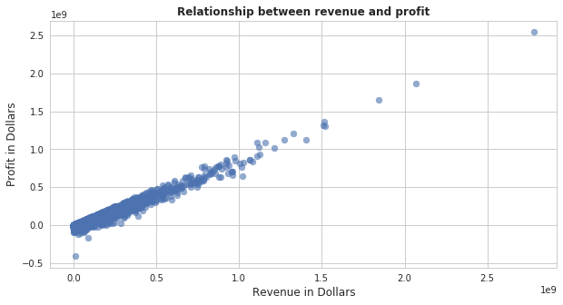

```python
# x-axis
plt.xlabel('Revenue in Dollars',fontsize=12)
# y-axis
plt.ylabel('Profit in Dollars',fontsize=12)
# Title of the histogram
plt.title('Relationship between revenue and profit',fontweight="bold", fontsize=12)
plt.scatter(df['revenue'], df['profit'], alpha=0.6)
plt.show()
#setup the figure size.
sns.set(rc={'figure.figsize':(10,5)})
sns.set_style("whitegrid")
```

We can see that there is a strong relationship between profit and revenue, higher the revenue, higher the profit.

Let us check if there a relation between the Budget and Revenue

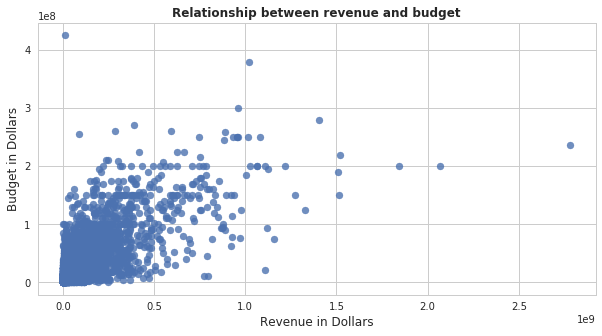

```python
# x-axis
plt.xlabel('Revenue in Dollars',fontsize=12)
# y-axis
plt.ylabel('Budget in Dollars',fontsize=12)
# Title of the histogram
plt.title('Relationship between revenue and budget', fontweight="bold", fontsize=12)
plt.scatter(df['revenue'], df['budget'], alpha=0.8)
plt.show()
#setup the figure size.
sns.set(rc={'figure.figsize':(10,5)})
sns.set_style("whitegrid")
```

From the above plot what we observe is, Most of the movies have a revenue upto 50M Dollars.

### Research Question 1.4 What is the average runtime of all movies?

```python
# Average runtime of movies
df['runtime'].mean()
```

```
109.22029060716139
```

#### What is the average runtime of all movies?

> So the average runtime of the movies is 109.22 minutes

Let us plot a histogram to see the same.

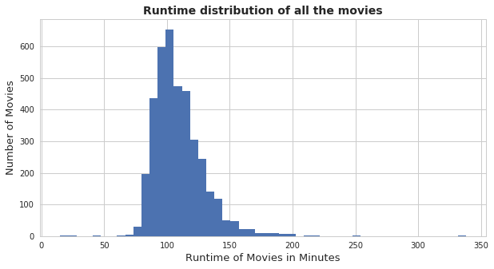

```python
# x-axis
plt.xlabel('Runtime of Movies in Minutes',fontsize=13)
# y-axis
plt.ylabel('Number of Movies', fontsize=13)
# Title of the histogram
plt.title('Runtime distribution of all the movies', fontsize=14, fontweight="bold")
# Plot a histogram
plt.hist(df['runtime'], bins = 50)
#setup the figure size.
sns.set(rc={'figure.figsize':(10,5)})
sns.set_style("whitegrid")
```

Let us check if there a relation between the Runtime and Profit

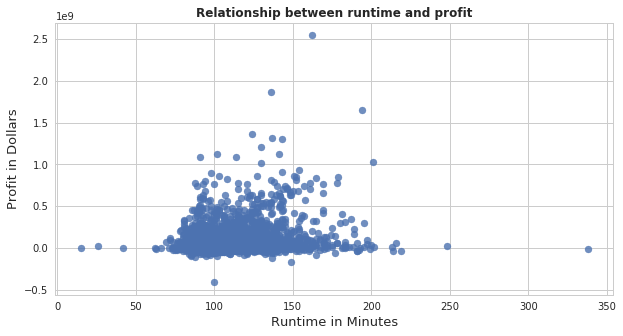

```python
# x-axis
plt.xlabel('Runtime in Minutes',fontsize = 13)
# y-axis
plt.ylabel('Profit in Dollars',fontsize = 13)
# Title of the histogram
plt.title('Relationship between runtime and profit',fontsize=12, fontweight="bold")
plt.scatter(df['runtime'], df['profit'], alpha=0.8)
plt.show()
#setup the figure size.
sns.set(rc={'figure.figsize':(10,5)})
sns.set_style("whitegrid")
```

Most of the movies have runtime in range of 85 to 120 Minutes.

### Research Question 1.5 Which duration movies are most liked by the audiences according to their popularity?

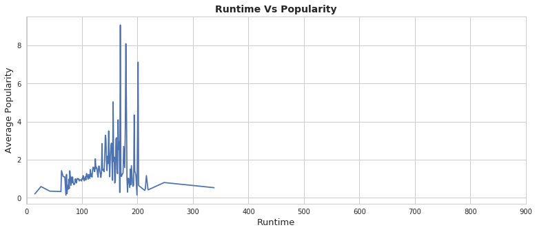

```python
#use groupby function and group the data according to their runtime.
#make a plot using their popularity and find which length movies are most popular.

#make the group of the data according to their runtime and find the mean popularity related to this and plot.
df.groupby('runtime')['popularity'].mean().plot(figsize = (13,5),xticks=np.arange(0,1000,100))

#setup the title of the figure
plt.title("Runtime Vs Popularity",fontsize = 14, fontweight="bold")

#setup the x-label and y-label of the plot
plt.xlabel('Runtime',fontsize = 13)
plt.ylabel('Average Popularity',fontsize = 13)

#setup the figure size.
sns.set(rc={'figure.figsize':(10,5)})
sns.set_style("whitegrid")
```

### Research Question 2.1 What is the average budget of the movie?

Now since in all the remaining questions we are going to answer them with respect to profit, we will now clean our datset and only incudde data of movies who made profit of more then 25M Dollars.

```python
# Dataframe which has data of movies which made profit of more the 25M Dollars.
tmdb_profit_data = df[df['profit'] >= 25000000]

# Reindexing the dataframe
tmdb_profit_data.index = range(len(tmdb_profit_data))

#showing the dataset
tmdb_profit_data.head()
```

|  | popularity | budget | revenue | original_title | cast | director | runtime | genres | production_companies | release_date | vote_count | vote_average | release_year | profit |
| --- | --- | --- | --- | --- | --- | --- | --- | --- | --- | --- | --- | --- | --- | --- |
| 0 | 32.985763 | 150000000 | 1513528810 | Jurassic World | Chris Pratt\|Bryce Dallas Howard\|Irrfan Khan\|Vi... | Colin Trevorrow | 124 | Action\|Adventure\|Science Fiction\|Thriller | Universal Studios\|Amblin Entertainment\|Legenda... | 2015-06-09 | 5562 | 6.5 | 2015 | 1363528810 |
| 1 | 28.419936 | 150000000 | 378436354 | Mad Max: Fury Road | Tom Hardy\|Charlize Theron\|Hugh Keays-Byrne\|Nic... | George Miller | 120 | Action\|Adventure\|Science Fiction\|Thriller | Village Roadshow Pictures\|Kennedy Miller Produ... | 2015-05-13 | 6185 | 7.1 | 2015 | 228436354 |
| 2 | 13.112507 | 110000000 | 295238201 | Insurgent | Shailene Woodley\|Theo James\|Kate Winslet\|Ansel... | Robert Schwentke | 119 | Adventure\|Science Fiction\|Thriller | Summit Entertainment\|Mandeville Films\|Red Wago... | 2015-03-18 | 2480 | 6.3 | 2015 | 185238201 |
| 3 | 11.173104 | 200000000 | 2068178225 | Star Wars: The Force Awakens | Harrison Ford\|Mark Hamill\|Carrie Fisher\|Adam D... | J.J. Abrams | 136 | Action\|Adventure\|Science Fiction\|Fantasy | Lucasfilm\|Truenorth Productions\|Bad Robot | 2015-12-15 | 5292 | 7.5 | 2015 | 1868178225 |
| 4 | 9.335014 | 190000000 | 1506249360 | Furious 7 | Vin Diesel\|Paul Walker\|Jason Statham\|Michelle ... | James Wan | 137 | Action\|Crime\|Thriller | Universal Pictures\|Original Film\|Media Rights ... | 2015-04-01 | 2947 | 7.3 | 2015 | 1316249360 |

```python
# Checking the new dataframe
tmdb_profit_data.info()
```

```
<class 'pandas.core.frame.DataFrame'>
RangeIndex: 1791 entries, 0 to 1790
Data columns (total 14 columns):
popularity              1791 non-null float64
budget                  1791 non-null int64
revenue                 1791 non-null int64
original_title          1791 non-null object
cast                    1790 non-null object
director                1791 non-null object
runtime                 1791 non-null int64
genres                  1791 non-null object
production_companies    1788 non-null object
release_date            1791 non-null datetime64[ns]
vote_count              1791 non-null int64
vote_average            1791 non-null float64
release_year            1791 non-null int64
profit                  1791 non-null int64
dtypes: datetime64[ns](1), float64(2), int64(6), object(5)
memory usage: 196.0+ KB
```

```python
# average budget of movies which made profit more than 25B dollars
tmdb_profit_data['budget'].mean()
```

```
51870307.757118925
```

#### What is the average budget of the movie w.r.t Profit of movies making more then 25M Dollars?¶

> So the average budget of the movies is 51870307.75 Dollars

### Research Question 2.2 What is the average revenue of the movie?

```python
# average revenue of movies which made profit more then 25M Dollars
tmdb_profit_data['revenue'].mean()
```

```
206359440.87269682
```

#### What is the average revenue of the movie w.r.t Profit of movies making more then 25M Dollars?

> So the average revenue of the movies is 206359440.87 Dollars

### Research Question 2.3 Which are the most frequent cast involved?

```python
# This will first concat all the data with | from the whole column and then split it using | and count the number of times it occured.
cast_count = pd.Series(tmdb_profit_data['cast'].str.cat(sep = '|').split('|')).value_counts(ascending = False)
cast_count.head(20)
```

```
Tom Cruise               29
Tom Hanks                28
Brad Pitt                27
Robert De Niro           26
Bruce Willis             25
Cameron Diaz             24
Samuel L. Jackson        23
Eddie Murphy             23
Sylvester Stallone       22
Mark Wahlberg            22
Johnny Depp              22
George Clooney           20
Adam Sandler             20
Denzel Washington        20
Harrison Ford            20
Robin Williams           20
Jim Carrey               20
Matt Damon               20
Arnold Schwarzenegger    19
Ben Stiller              19
dtype: int64
```

#### Which are the most frequent cast involved w.r.t Profit of movies making more then 25M Dollars?

> So the Top 5 cast are Tom Cruise, Tom Hanks, Brad Pitt, Robert De Niro, Bruce Willis

Lets visualize this with a plot

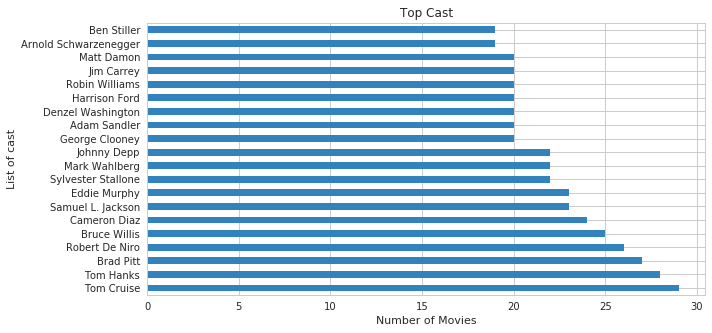

```python
# Initialize the plot
figure = cast_count.head(20).plot.barh(fontsize = 10,colormap= 'tab20c')
# Set a title
figure.set(title = 'Top Cast')
# x-label and y-label
figure.set_xlabel('Number of Movies')
figure.set_ylabel('List of cast')
# Show the plot
plt.show()
#setup the figure size.
sns.set(rc={'figure.figsize':(10,5)})
sns.set_style("whitegrid")
```

### Research Question 2.4 Which are the successful genres?

```python
# This will first concat all the data with | from the whole column and then split it using | and count the number of times it occured.
genres_count = pd.Series(tmdb_profit_data['genres'].str.cat(sep = '|').split('|')).value_counts(ascending = False)
genres_count
```

```
Drama              688
Comedy             645
Action             566
Thriller           542
Adventure          451
Romance            292
Crime              287
Family             265
Science Fiction    250
Fantasy            227
Horror             191
Mystery            150
Animation          136
Music               62
History             59
War                 58
Western             20
Documentary          9
Foreign              1
TV Movie             1
dtype: int64
```

#### Which are the successful genres w.r.t Profit of movies making more then 25M Dollars?

> The Top 10 Genres are Drama, Comedy, Action, Thriller, Adventure, Romance, Crime, Family, Scince Fiction, Fantasy

Lets visualize this with a plot

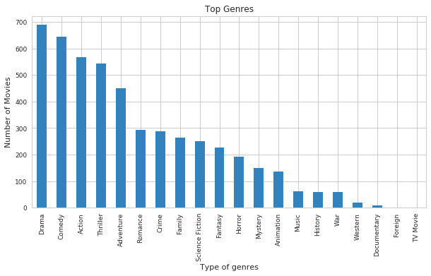

```python
# Initialize the plot
diagram = genres_count.plot.bar(fontsize = 9, colormap= 'tab20c')
# Set a title
diagram.set(title = 'Top Genres')
# x-label and y-label
diagram.set_xlabel('Type of genres')
diagram.set_ylabel('Number of Movies')
# Show the plot
plt.show()
#setup the figure size.
sns.set(rc={'figure.figsize':(10,5)})
sns.set_style("whitegrid")
```

#### Conclusions

Based on the analysis for profit more than 25M dollars, we have found the following:

> The average budget of the movies can be around 51870307.75 Dollars

> The Top 10 Genres we should focus on should be Drama, Comedy, Action, Thriller, Adventure, Romance, Crime, Family, Scince Fiction, Fantasy

> The average revenue of the movies will be around 206359440.87 Dollars

> The Top 5 cast we should focus on should be Tom Cruise, Tom Hanks, Brad Pitt, Robert De Niro, Bruce Willis

#### Limitations :

Findings are tentative and not verified by the principles of statistics and machine learning.The conclusion is not full proof that this formula is gonna work, but it shows us that we have high probability of making high profits if we had similar characteristics as such.This was just one example of an influential factor that would lead to different results, there are many that have to be taken care of.

```python
from subprocess import call
call(['python', '-m', 'nbconvert', 'Investigate_a_Dataset.ipynb'])
```

```
0
```